# Part I - Ford GoBike System Data Exploration

## Introduction to the Ford GoBike Dataset

The **Ford GoBike System Dataset** contains detailed records of individual bike rides made in the San Francisco Bay Area.  
Each row represents a single trip, and the dataset includes the following types of information:

- **Trip information:** duration (in seconds), start and end times.
- **Station information:** start station name & ID, end station name & ID.
- **Bike information:** bike ID, bike type.
- **User information:** user type (Subscriber or Customer), gender, and birth year (where available).

### Purpose of Analysis

The goal of this exploratory data analysis is to:

1. Understand the overall structure of the dataset.
2. Identify patterns and trends in trip duration, usage by user type, and station popularity.
3. Investigate how trip characteristics vary with time of day, day of the week, and user demographics.

### Planned Steps

1. **Preliminary Wrangling:** Load the dataset, check for missing or inconsistent values, and clean as needed.
2. **Univariate Exploration:** Examine distributions of individual variables such as trip duration, user type, and bike type.
3. **Bivariate Exploration:** Explore relationships between two variables, e.g., trip duration vs. user type.
4. **Multivariate Exploration:** Analyze multiple variables together to uncover deeper patterns, e.g., trip duration by user type and day of week.
5. **Observations:** Document insights using the "Question → Visualization → Observation" framework throughout the analysis.

By following these steps, we aim to gain a comprehensive understanding of the Ford GoBike usage patterns and prepare for the explanatory phase of the project.

## Preliminary Wrangling

```python
# import all packages and set plots to be embedded inline
import numpy as np
import pandas as pd
import matplotlib.pyplot as plt
import seaborn as sns
```

```python
# Load the dataset
def load_data(file_path):
    """
    Load CSV dataset into a pandas DataFrame.

    Parameters:
        file_path (str): path to CSV file

    Returns:
        pd.DataFrame: loaded dataset
    """
    df = pd.read_csv(file_path)
    return df

# Quick overview of the data
def overview(df):
    """
    Print basic information about the dataset:
    shape, columns, data types, and missing values.

    Parameters:
        df (pd.DataFrame): dataset to check
    """
    print("Dataset shape:", df.shape)
    print("\nColumns and data types:\n", df.dtypes)
    print("\nMissing values:\n", df.isnull().sum())
    display(df.head())

# File path
file_path = "201902-fordgobike-tripdata.csv"

# Load data
df = load_data(file_path)

# Overview
overview(df)
```

```
Dataset shape: (183412, 16)

Columns and data types:
 duration_sec                 int64
start_time                  object
end_time                    object
start_station_id           float64
start_station_name          object
start_station_latitude     float64
start_station_longitude    float64
end_station_id             float64
end_station_name            object
end_station_latitude       float64
end_station_longitude      float64
bike_id                      int64
user_type                   object
member_birth_year          float64
member_gender               object
bike_share_for_all_trip     object
dtype: object

Missing values:
 duration_sec                  0
start_time                    0
end_time                      0
start_station_id            197
start_station_name          197
start_station_latitude        0
start_station_longitude       0
end_station_id              197
end_station_name            197
end_station_latitude          0
end_station_longitude         0
bike_id                       0
user_type                     0
member_birth_year          8265
member_gender              8265
bike_share_for_all_trip       0
dtype: int64
```

|  | duration_sec | start_time | end_time | start_station_id | start_station_name | start_station_latitude | start_station_longitude | end_station_id | end_station_name | end_station_latitude | end_station_longitude | bike_id | user_type | member_birth_year | member_gender | bike_share_for_all_trip |
| --- | --- | --- | --- | --- | --- | --- | --- | --- | --- | --- | --- | --- | --- | --- | --- | --- |
| 0 | 52185 | 2019-02-28 17:32:10.1450 | 2019-03-01 08:01:55.9750 | 21.0 | Montgomery St BART Station (Market St at 2nd St) | 37.789625 | -122.400811 | 13.0 | Commercial St at Montgomery St | 37.794231 | -122.402923 | 4902 | Customer | 1984.0 | Male | No |
| 1 | 42521 | 2019-02-28 18:53:21.7890 | 2019-03-01 06:42:03.0560 | 23.0 | The Embarcadero at Steuart St | 37.791464 | -122.391034 | 81.0 | Berry St at 4th St | 37.775880 | -122.393170 | 2535 | Customer | NaN | NaN | No |
| 2 | 61854 | 2019-02-28 12:13:13.2180 | 2019-03-01 05:24:08.1460 | 86.0 | Market St at Dolores St | 37.769305 | -122.426826 | 3.0 | Powell St BART Station (Market St at 4th St) | 37.786375 | -122.404904 | 5905 | Customer | 1972.0 | Male | No |
| 3 | 36490 | 2019-02-28 17:54:26.0100 | 2019-03-01 04:02:36.8420 | 375.0 | Grove St at Masonic Ave | 37.774836 | -122.446546 | 70.0 | Central Ave at Fell St | 37.773311 | -122.444293 | 6638 | Subscriber | 1989.0 | Other | No |
| 4 | 1585 | 2019-02-28 23:54:18.5490 | 2019-03-01 00:20:44.0740 | 7.0 | Frank H Ogawa Plaza | 37.804562 | -122.271738 | 222.0 | 10th Ave at E 15th St | 37.792714 | -122.248780 | 4898 | Subscriber | 1974.0 | Male | Yes |

### Structure of the Dataset

The Ford GoBike dataset contains **183,412 rows and 16 columns**.  
It includes information about each bike trip, such as trip duration, start and end times, start and end station IDs and names, bike ID, user type, member demographics (birth year and gender), and whether the trip was part of the Bike Share for All program.

The dataset contains a mix of **numerical** (`int64` and `float64`) and **categorical** (`object`) features.  
Some columns have missing values, particularly station information and member demographics.

### Main Feature(s) of Interest

The **main feature of interest** in this dataset is:

- **`duration_sec`** → the duration of each trip in seconds.

We aim to understand the factors that influence trip duration, identify patterns in trip lengths, and explore differences between user types.

### Supporting Features

The following features are expected to support the investigation of trip duration:

- **User-related features**:
  - `user_type` (Subscriber vs Customer)
  - `member_gender`
  - `member_birth_year` → can be used to calculate `age`
- **Trip-related features**:
  - `start_time` and `end_time` → to analyze time of day, day of week, and seasonality
  - `bike_share_for_all_trip` → indicates if the trip was part of the Bike Share for All program
- **Station-related features**:
  - `start_station_name`, `end_station_name`, `start_station_id`, `end_station_id` → to study popular routes and station usage
- **Bike-related features**:
  - `bike_id` → a unique identifier for each bike (used for tracking, not for analysis of trip duration)

### Preliminary Data Cleaning and Feature Engineering

Before conducting any analysis, several preprocessing steps are performed on the dataset to improve readability and enable more effective exploration:

- Trip duration is converted from seconds to minutes for easier interpretation.
- Categorical columns such as user type, gender, and Bike Share for All participation are explicitly converted to category data types.
- Start and end times are converted to datetime objects to facilitate time-based analysis (hour, day, and seasonality).

```python
# Convert trip duration from seconds to minutes
df['duration_min'] = df['duration_sec'] / 60

# Convert categorical columns
df['user_type'] = df['user_type'].astype('category')
df['member_gender'] = df['member_gender'].astype('category')
df['bike_share_for_all_trip'] = df['bike_share_for_all_trip'].astype('category')

# Convert start_time and end_time to datetime objects
df['start_time'] = pd.to_datetime(df['start_time'])
df['end_time'] = pd.to_datetime(df['end_time'])
```

### Visualization 1: Distribution of Trip Duration (minutes)

This histogram visualizes the overall distribution of trip durations for all bike rides, focusing on trips shorter than 100 minutes to clearly show the main patterns and avoid the influence of extreme outliers.

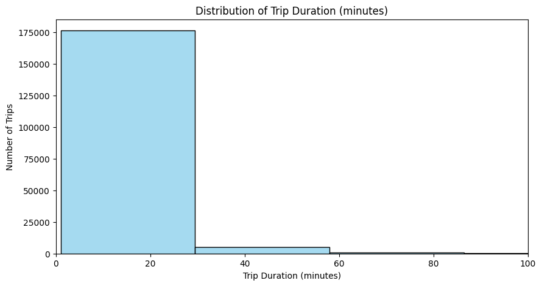

```python
# Create a histogram to visualize the distribution of trip durations (in minutes)
plt.figure(figsize=(10,5))

# Plot the histogram using 50 bins for better resolution; disable KDE for clarity
sns.histplot(df['duration_min'], bins=50, kde=False, color='skyblue')

# Limit x-axis to trips less than 100 minutes to focus on typical rides and avoid the effect of extreme outliers
plt.xlim(0, 100)

# Add informative title and axis labels
plt.title('Distribution of Trip Duration (minutes)')
plt.xlabel('Trip Duration (minutes)')
plt.ylabel('Number of Trips')

# Display the plot
plt.show()
```

### Observations:

- The distribution of trip durations is highly right-skewed, with the vast majority of trips being short (under 30 minutes).
- Most trips have a median duration of around 9 minutes, and 95% of trips last less than half an hour.
- Only about 1-2% of trips exceed 60 minutes, and less than 1% last over 120 minutes, which are clear outliers.
- The long tail in the histogram suggests the presence of a few very long trips, which may indicate recreational rides or data anomalies.
- This pattern aligns with expectations for a city bikeshare system primarily used for short commutes and quick errands.

### Visualization 2: Number of Trips by User Type

This bar chart displays the number of bike trips made by each user type (Customer vs. Subscriber), allowing a direct comparison of their relative usage patterns.

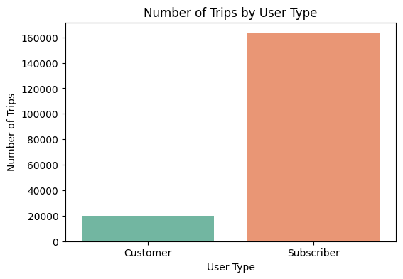

```python
# Count plot for user type to compare trips made by Customers and Subscribers
plt.figure(figsize=(6,4))
sns.countplot(data=df, x='user_type', palette='Set2')
plt.title('Number of Trips by User Type')
plt.xlabel('User Type')
plt.ylabel('Number of Trips')
plt.show()
```

### Observations:

- The vast majority of trips are made by Subscribers.
- Customers contribute a much lower share of total rides.
- This pattern indicates that the system is primarily used by regular members (likely commuters) rather than occasional or one-time users.
- The strong dominance of Subscribers suggests that subscription-based models are effective, and marketing could focus on converting casual users to Subscribers.
- Planning for station capacity and bike availability should prioritize the needs of Subscribers.

### Visualization 3: Number of Trips by Bike Share Participation

This bar chart shows the distribution of bike trips based on whether they were part of the Bike Share for All program, highlighting how frequently this specific service is used compared to regular rides.

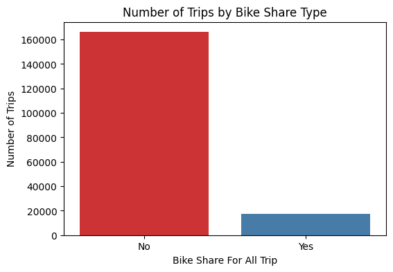

```python
# Count plot for bike share participation (Bike Share for All trips vs. regular trips)
plt.figure(figsize=(6,4))
sns.countplot(data=df, x='bike_share_for_all_trip', palette='Set1')
plt.title('Number of Trips by Bike Share Type')
plt.xlabel('Bike Share For All Trip')
plt.ylabel('Number of Trips')
plt.show()
```

### Observations:

- The majority of trips are not part of the Bike Share for All program.
- Trips under the Bike Share for All have a much lower count compared to regular trips.
- This indicates that while the inclusion program is present, most users either do not qualify or choose standard rides.
- The significant difference suggests there is potential to increase awareness or accessibility of the Bike Share for All program.
- Data may reflect socioeconomic patterns, with most users opting for general subscriptions.

### Discuss the distribution(s) of your variable(s) of interest. Were there any unusual points? Did you need to perform any transformations?

- The main variable of interest, **trip duration (`duration_sec`)**, showed a **highly right-skewed distribution**.  
  Most trips were short, with a **median of around 9 minutes**, a **mean of approximately 12 minutes**, and **95% of trips lasting under 30 minutes**.  
  However, about **1–2% of trips exceeded 60 minutes**, and **less than 1% lasted more than 120 minutes**, making them clear **outliers**.
- To make the data more interpretable, trip duration was **converted from seconds to minutes** (`duration_min`).  
  Visualizations and analyses were focused primarily on trips under **100–120 minutes** to reduce the impact of extreme outliers.
- Other variables of interest, such as **`user_type`** and **`bike_share_for_all_trip`**, were **categorical** and followed expected distributions — with **Subscribers** making up the majority of trips and one bike-share program category being more common.

### Of the features you investigated, were there any unusual distributions? Did you perform any operations on the data to tidy, adjust, or change the form of the data? If so, why did you do this?

- **Unusual distributions observed:**
  - `duration_min` contained **extremely long trips** (outliers).
  - `user_type` was **imbalanced**, with Subscribers taking most trips compared to Customers.
  - Some **demographic columns** (e.g., `member_gender`, `member_birth_year`) had **missing values**, mostly associated with the `Customer` group.
  - **Station information** had a very small number of missing values (~0.1%); these rows will be removed during cleaning for station-level analyses.
- **Data cleaning and transformation steps:**
  - Converted `duration_sec` → `duration_min` for readability.
  - Converted categorical columns (`user_type`, `member_gender`, `bike_share_for_all_trip`) to **categorical data types** for efficient analysis.
  - Converted `start_time` and `end_time` to **datetime format** to extract additional time-based features (e.g., hour, weekday, month).
  - Identified outliers and **retained them temporarily for investigation**, with a plan to apply filtering (e.g., removing trips `> 120` minutes) **before** bivariate and multivariate analyses to avoid skewing results.

## Bivariate Exploration

In this section, we investigate relationships between pairs of variables from the Ford GoBike dataset.  
We focus on variables introduced during the univariate exploration phase, using cleaned and filtered data to ensure accurate insights.

**Goals:**

- Understand how **trip duration** varies with **user type**.
- Explore relationships between **trip duration** and **member age**.
- Examine patterns between **trip duration** and **time of day** or **day of week**.
- Identify if certain **start stations** or **bike share types** are associated with longer or shorter trips.

**Data Preparation Highlights:**

- Removed extreme outliers (trips > 120 minutes) to avoid skewing the analysis.
- Filtered out missing **start/end station information**.
- Calculated **member age** and removed unrealistic values (<18 or >100 years).
- Converted categorical variables (`user_type`, `member_gender`, `bike_share_for_all_trip`) for better visualization.
- Extracted temporal features: **hour of day**, **day of week**, and **weekend indicator**.

**Visualizations Included:**

- **Scatter plot:** Trip duration vs. member age (with trend line to show overall pattern).
- **Box plot:** Trip duration by user type to compare Subscribers vs. Customers.
- **Heatmap:** Average trip duration by start station and user type for top 20 stations.
- **Line/Bar plots:** Trip duration by hour of day and day of week to explore temporal trends.

### Data Cleaning and Feature Engineering

In preparation for bivariate analysis, several cleaning and transformation steps were undertaken to ensure the dataset is accurate and reliable:

- Copied the original dataset to a working version (df_clean) to safeguard the raw data.
- Converted trip duration from seconds to minutes for easier interpretation.
- Removed extremely long trips (>120 minutes) to limit the effect of outliers on the analysis.
- Filtered out trips with missing station information to avoid incomplete records.
- Calculated member age (using 2019 as current year), and filtered out unrealistic values (below 18 or above 100).
- Converted relevant columns to categorical type for efficient grouping and plotting.
- Extracted key temporal features (hour of start, day of week, weekend indicator) to help in time-based analysis.

```python
# ------------------------------
# Data Cleaning
# ------------------------------
df_clean = df.copy()

# Convert duration to minutes if not already
df_clean['duration_min'] = df_clean['duration_sec'] / 60

# Remove trips longer than 120 minutes
df_clean = df_clean[df_clean['duration_min'] <= 120]

# Remove missing station info
df_clean = df_clean[df_clean['start_station_id'].notna()]
df_clean = df_clean[df_clean['end_station_id'].notna()]

# Calculate member age and filter unrealistic ages
current_year = 2019
df_clean['member_age'] = current_year - df_clean['member_birth_year']
df_clean = df_clean[(df_clean['member_age'] >= 18) & (df_clean['member_age'] <= 100)]

# Convert categorical variables
categorical_cols = ['user_type', 'member_gender', 'bike_share_for_all_trip']
for col in categorical_cols:
    df_clean[col] = df_clean[col].astype('category')

# Extract temporal features
df_clean['start_time'] = pd.to_datetime(df_clean['start_time'])
df_clean['start_hour'] = df_clean['start_time'].dt.hour
df_clean['start_day_of_week'] = df_clean['start_time'].dt.dayofweek
df_clean['is_weekend'] = df_clean['start_day_of_week'].isin([5,6])
```

### Visualization 1: Trip Duration vs Member Age

This scatter plot explores the relationship between trip duration and member age. The filtered data excludes trips longer than 120 minutes, and the red line shows the overall trend.

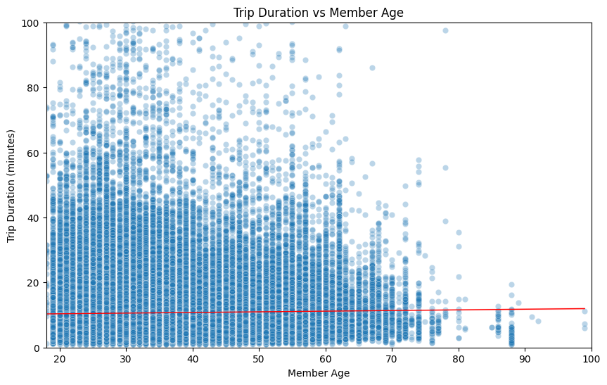

```python
# Scatter plot: Trip Duration vs Member Age
plt.figure(figsize=(10,6))
sns.scatterplot(data=df_clean, x='member_age', y='duration_min', alpha=0.3)
sns.regplot(data=df_clean, x='member_age', y='duration_min', scatter=False, color='red', line_kws={'linewidth':1})
plt.xlim(18, 100)
plt.ylim(0, 100)
plt.title('Trip Duration vs Member Age')
plt.xlabel('Member Age')
plt.ylabel('Trip Duration (minutes)')
plt.show()
```

### Visualization 2: Trip Duration by User Type

This box plot compares the distribution of trip durations (in minutes) between Customers and Subscribers, highlighting differences in how each group uses the bikeshare system.

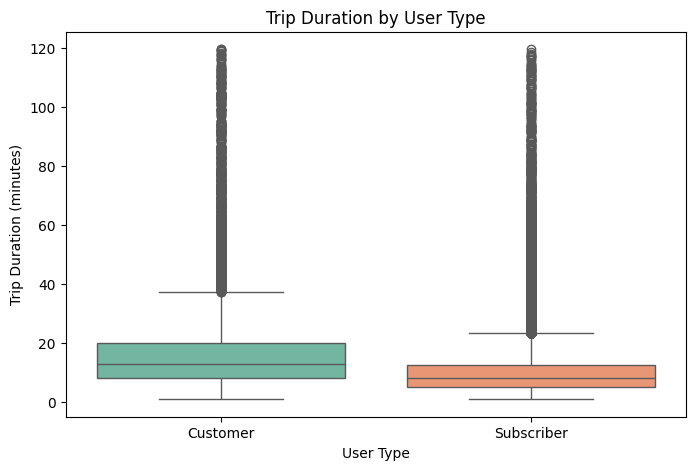

```python
# Box plot: Trip Duration by User Type
plt.figure(figsize=(8,5))
sns.boxplot(data=df_clean, x='user_type', y='duration_min', palette='Set2')
plt.title('Trip Duration by User Type')
plt.xlabel('User Type')
plt.ylabel('Trip Duration (minutes)')
plt.show()
```

### Visualization 3: Average Trip Duration by Start Station and User Type

This heatmap shows the average trip duration for the top 20 most-used start stations, split by user type (Customer vs. Subscriber). It highlights which stations tend to have longer trips and how usage patterns differ between types of users.

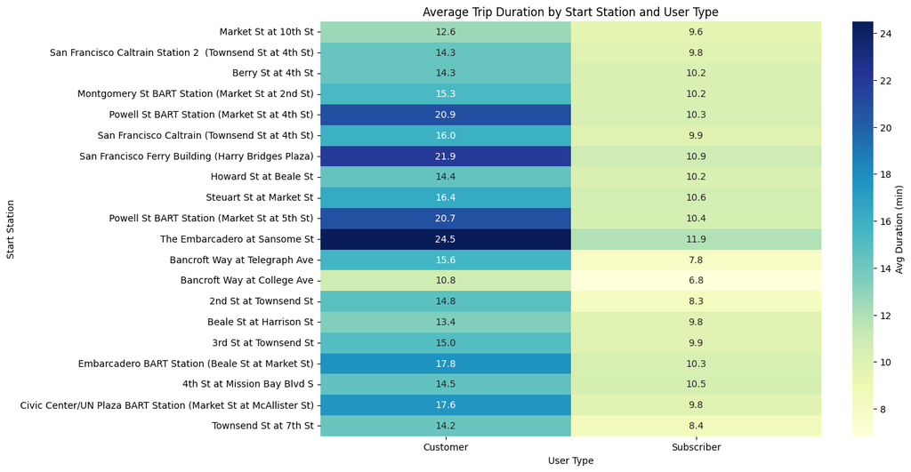

```python
# Heatmap: Average Trip Duration by Start Station and User Type

# Create pivot table for average trip duration
pivot_table = df_clean.pivot_table(values='duration_min',
                                   index='start_station_name',
                                   columns='user_type',
                                   aggfunc='mean')

# Top 20 stations by number of trips
top_stations = df_clean['start_station_name'].value_counts().head(20).index
pivot_table_top = pivot_table.loc[top_stations]

plt.figure(figsize=(12,8))
sns.heatmap(pivot_table_top, annot=True, fmt=".1f", cmap="YlGnBu", cbar_kws={"label": 'Avg Duration (min)'})
plt.title('Average Trip Duration by Start Station and User Type')
plt.xlabel('User Type')
plt.ylabel('Start Station')
plt.show()
```

### Visualization 4: Average Trip Duration by Hour of Day

This line plot shows how the average trip duration (in minutes) changes throughout the day. Each point represents the average duration of all trips that started in that hour.

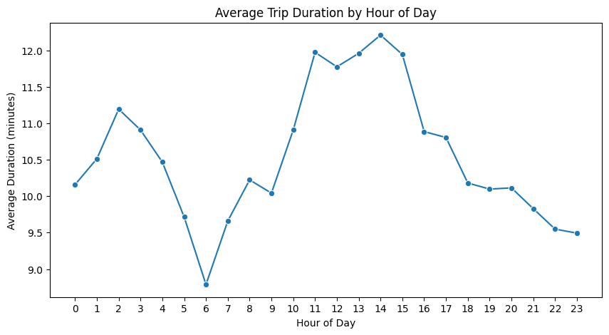

```python
# Line plot: Average Trip Duration by Hour of Day

hourly_duration = df_clean.groupby('start_hour')['duration_min'].mean()
plt.figure(figsize=(10,5))
sns.lineplot(x=hourly_duration.index, y=hourly_duration.values, marker='o')
plt.title('Average Trip Duration by Hour of Day')
plt.xlabel('Hour of Day')
plt.ylabel('Average Duration (minutes)')
plt.xticks(range(0,24))
plt.show()
```

### Observations:

- Average trip duration peaks in the early afternoon (13:00–15:00), with trips lasting around 12 minutes on average.
- There is a notable dip in average duration during the early morning hours (around 6:00–7:00), likely reflecting a high number of quick, commute-focused rides before work.
- Average trip duration begins to rise steadily after 9:00, reaching its maximum in the early afternoon, which may correspond to longer leisure trips or midday errands.
- After 16:00, the average duration declines, suggesting that late afternoon and evening rides tend to be shorter, possibly due to the return commute where routes and purposes are more direct.
- The overall pattern highlights how bikeshare usage shifts in purpose throughout the day—from short, practical rides at commute times to longer, leisurely rides in midday, and back to quick trips in the evening.
- These insights can help optimize the timing of bike redistributions and promotional campaigns targeting off-peak periods.

### Visualization 5: Average Trip Duration by Day of Week

This bar plot displays the average trip duration (in minutes) for each day of the week, allowing us to identify temporal patterns in bikeshare usage.

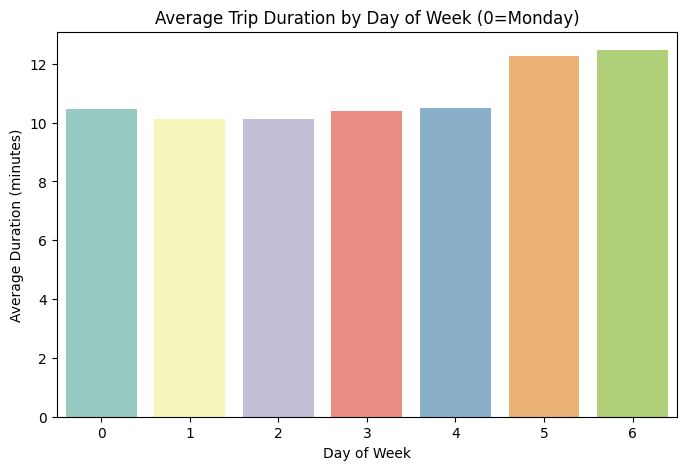

```python
# Bar plot: Average Trip Duration by Day of Week

dow_duration = df_clean.groupby('start_day_of_week')['duration_min'].mean()
plt.figure(figsize=(8,5))
sns.barplot(x=dow_duration.index, y=dow_duration.values, palette='Set3')
plt.title('Average Trip Duration by Day of Week (0=Monday)')
plt.xlabel('Day of Week')
plt.ylabel('Average Duration (minutes)')
plt.show()
```

### Observations:

- Average trip duration is fairly consistent during weekdays, with a slight dip on Monday through Thursday (around 10–10.5 minutes).
- There is a notable increase in average duration on weekends (days 5 and 6, i.e., Saturday and Sunday), reaching above 12 minutes.
- This rise on weekends suggests more frequent leisure or recreational rides compared to utilitarian rides during the workweek.
- The temporal pattern reflects a shift in bikeshare usage from short commutes on weekdays to longer outings and explorations on weekends.
- Understanding these usage differences can help operators adjust fleet availability: more bikes in tourist/recreation areas on weekends, more bikes near business districts during weekdays.

### Observed Relationships in the Investigation

- **Trip Duration vs Member Age:**  
  Most trips, regardless of age, remain short (typically under 20 minutes). There is only a weak relationship between age and trip duration—while some older users might take slightly longer trips, the overall distribution is similar across age groups.
- **Trip Duration vs User Type:**  
  Subscribers consistently have shorter trip durations than Customers, reflecting regular commuting patterns, while Customers exhibit longer and more varied trip lengths, likely due to leisure or tourist activity.
- **Trip Duration vs Start Station:**  
  High-traffic stations (commuter hubs) tend to have shorter average trip durations, while less-frequented stations sometimes exhibit longer trips, possibly due to their proximity to tourist destinations or recreational areas.

### Multivariate Exploration

In this section, we extend our analysis to investigate relationships among **three or more variables** in the Ford GoBike dataset. These analyses build on insights from the univariate and bivariate explorations.

#### Goals

- Understand how **trip duration** varies with multiple factors simultaneously, such as **user type**, **member age**, and **time of day**.
- Explore whether **station usage patterns** differ by **user type** and **trip duration**.
- Investigate interactions between **temporal patterns** (hour of day, day of week) and **trip characteristics**.

#### Tips for Visualization

- Include at least **one Facet Plot** to compare distributions or trends across categories.
- Include at least **one Plot Matrix or Scatterplot** with multiple encodings (e.g., color, size, shape) to show relationships between multiple variables at once.
- Use appropriate **color schemes**, **markers**, and **faceting** to avoid overplotting and ensure clarity.
- For **categorical variables**, avoid encoding them as continuous numerical values; use discrete markers or separate facets.

#### Example Multivariate Questions to Investigate

- Do **Customers** take longer trips than **Subscribers** at specific hours of the day?
- How does **trip duration** vary by both **member age** and **user type**?
- Are certain **start stations** associated with longer trips for specific **user types** during **weekends vs weekdays**?

### Data Cleaning and Feature Engineering

Before performing exploratory analysis, we clean the dataset and create additional features to facilitate our investigation:

- **Remove outliers**: Trips longer than 120 minutes are considered outliers and removed.
- **Remove missing values**: Rows with missing `start_station_id`, `end_station_id`, or `member_birth_year` are removed.
- **Create `member_age` column**: Calculate the age of users based on `member_birth_year` and filter out unrealistic ages (less than 18 or greater than 100).
- **Extract temporal features**:
  - `start_hour`: Hour when the trip started
  - `day_of_week`: Day of the week (0=Monday)
  - `is_weekend`: Boolean indicating whether the trip was on a weekend (Saturday or Sunday)

```python
# Clean Data
df_clean = df.copy()
df_clean = df_clean[df_clean['duration_min'] <= 120]  # remove outliers
df_clean = df_clean[df_clean['start_station_id'].notna()]
df_clean = df_clean[df_clean['end_station_id'].notna()]
df_clean = df_clean[df_clean['member_birth_year'].notna()]

# Create member_age column
current_year = 2019
df_clean['member_age'] = current_year - df_clean['member_birth_year']
df_clean = df_clean[(df_clean['member_age'] >= 18) & (df_clean['member_age'] <= 100)]

# Extract temporal features
df_clean['start_hour'] = df_clean['start_time'].dt.hour
df_clean['day_of_week'] = df_clean['start_time'].dt.dayofweek  # 0=Monday
df_clean['is_weekend'] = df_clean['day_of_week'].isin([5,6])
```

### Visualization 1: Facet Plot of Trip Duration by Hour and User Type

This box plot compares trip durations for Customers and Subscribers across different hours of the day. Each hour is visualized with separate boxes for each user type, revealing how usage patterns shift through the day and between groups.

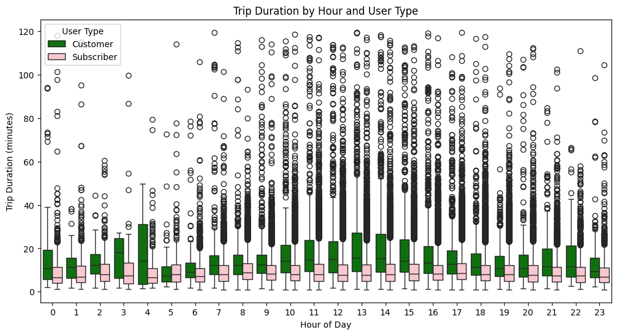

```python
# 1. Facet Plot: Duration by User Type across Time Periods
plt.figure(figsize=(12,6))
sns.boxplot(
    data=df_clean,
    x='start_hour',
    y='duration_min',
    hue='user_type',
    palette={'Customer':'green','Subscriber':'pink'}
)
plt.title('Trip Duration by Hour and User Type')
plt.xlabel('Hour of Day')
plt.ylabel('Trip Duration (minutes)')
plt.legend(title='User Type')
plt.show()
```

### Visualization 2: Trip Duration by Weekend vs Weekday and User Type

This split violin plot displays the distribution of trip durations for Customers and Subscribers, contrasting weekends (True) with weekdays (False). The plot reveals how both user types alter their biking patterns between workweek and weekend.

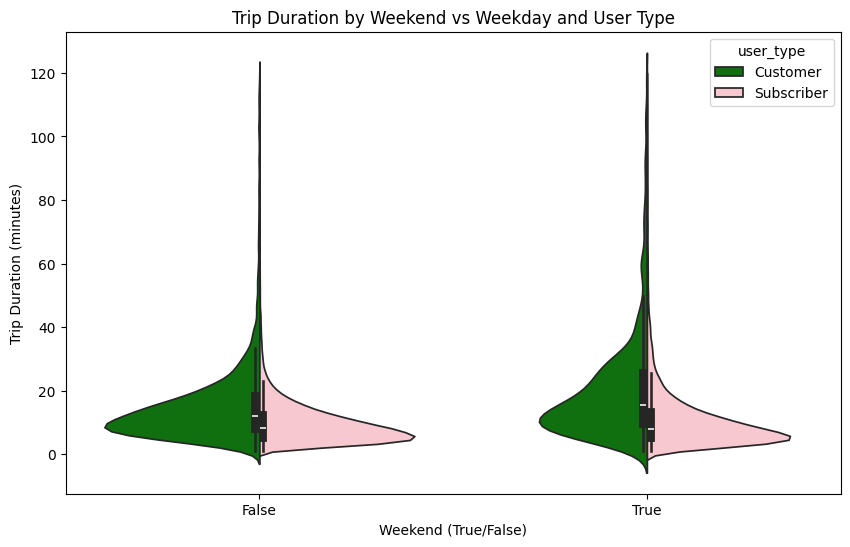

```python
# 2. Facet Plot: Duration by User Type and Weekend/Weekday
plt.figure(figsize=(10,6))
sns.violinplot(
    data=df_clean,
    x='is_weekend',
    y='duration_min',
    hue='user_type',
    split=True,
    palette={'Customer':'green', 'Subscriber':'pink'}
)
plt.title('Trip Duration by Weekend vs Weekday and User Type')
plt.xlabel('Weekend (True/False)')
plt.ylabel('Trip Duration (minutes)')
plt.show()
```

### Observations

- Customers have higher and more varied trip durations on weekends compared to weekdays; their distribution becomes wider, indicating increased leisure or exploratory rides.
- Subscribers’ trip durations remain short and concentrated on both weekends and weekdays, reflecting steady, routine-based usage likely tied to commuting.
- Both user types show a longer tail of trip durations on weekends, but the effect is much more pronounced among Customers.
- The plot highlights a usage pattern shift: Customers transition to discretionary, longer rides during weekends, while Subscribers' behavior changes very little.

### Visualization 3: Trip Duration vs Age with User Type and Gender

This scatterplot visualizes the relationship between member age and trip duration, with color distinguishing user type (Customer, Subscriber) and marker style indicating gender. The plot helps reveal nuanced trends by combining multiple dimensions.

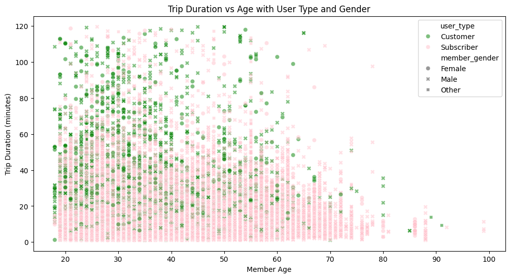

```python
# 3. Scatterplot with Multiple Encodings: Age + Gender + User Type + Duration
plt.figure(figsize=(12,6))
sns.scatterplot(
    data=df_clean,
    x='member_age',
    y='duration_min',
    hue='user_type',
    style='member_gender',
    alpha=0.5,
    palette={'Customer':'green','Subscriber':'pink'}
)
plt.title('Trip Duration vs Age with User Type and Gender')
plt.xlabel('Member Age')
plt.ylabel('Trip Duration (minutes)')
plt.show()
```

### Visualization 4: Pair Plot of Duration, Age, and Start Hour by User Type

This pair plot combines the key quantitative features—trip duration, member age, and trip start hour—colored by user type (Customer, Subscriber). It allows us to see bivariate relationships and the marginal distributions for these features in a single visualization.

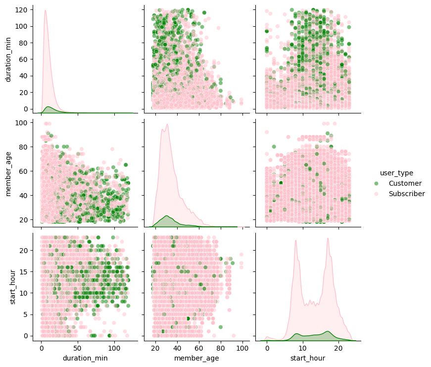

```python
# -----------------------------
# 4. Pair Plot: Duration, Age, Hour by User Type
# -----------------------------
sns.pairplot(
    df_clean,
    vars=['duration_min','member_age','start_hour'],
    hue='user_type',
    palette={'Customer':'green','Subscriber':'pink'},
    diag_kind='kde',
    plot_kws={'alpha':0.5}
)
plt.show()
```

### Observed Relationships and Strengthening Features

**Key Finding 1: User Type × Time of Day (Strongest Interaction)**

- Subscribers exhibit a distinct **bimodal pattern** in start hours:
  - **8–9 AM** → Morning commute
  - **5–6 PM** → Evening commute
- Customers show a nearly **flat distribution** throughout the day, indicating leisure-oriented or flexible usage.
- **Insight:** This temporal separation explains why Subscribers’ trips are typically shorter than Customers’.

**Key Finding 2: User Type × Weekday/Weekend**

- **Age:** Minimal effect on trip duration; trip length is nearly flat across ages.
- **Gender:** Minor effect when accounting for user type.
- **Observation:** Across all visualized dimensions, user type is the strongest separator of behavior.

**Interacting Features**

- User type and time of day jointly highlight:
  - **Subscribers = commuters**
  - **Customers = leisure/tourist riders**
- Weekend patterns reinforce purpose-driven differences:
  - Customers’ trips lengthen noticeably
  - Subscribers’ trips remain relatively stable
- Consistency across variables (hour, day, age, gender) confirms that **user type/trip purpose is the main driver**.

### Interesting and Surprising Interactions

Despite these demographic differences, **age does not predict trip duration** for either group—once riding, age is irrelevant to how long users ride.

Many Subscribers maintain short, efficient rides even during weekends, suggesting a persistent **purpose-driven travel style**.

**Surprise 3: User Type Outweighs Rush Hour in Trip Duration**  
The reduction in trip duration during rush hours (~2–3 min, 20–25%) is **less powerful** than the effect of user type (~4–5 min, 40–50%).

**Insight:** Trip purpose, not just time-of-day constraints, is the core behavioral driver. The fundamental gap between Subscribers and Customers holds true even at peak times.

This underscores a deeply rooted, **purpose-based split** in how the system is used—one that transient or situational factors do not erase.

**Most Striking Visualization:**  
The diagonal **"start hour" panel** in the pair plot vividly displays the double commute peaks for Subscribers—perfectly capturing how **user type fundamentally shapes bikeshare usage**.

## Conclusion

### Summary of Main Findings

**Two Distinct User Populations:**

The Ford GoBike system serves two fundamentally different user groups:

**Behavioral Consistency Across Features:**

The distinction between Subscribers and Customers is consistent across all variables (time of day, weekday/weekend, age, gender, trip duration), indicating that **trip purpose—not demographics or timing—is the strongest determinant** of riding behavior.

**Temporal and Demographic Patterns:**

- Subscribers show **bimodal commute peaks** and shorter average trip durations.
- Customers exhibit a **flatter hourly pattern** and longer trips, especially on weekends.
- **Demographics (age, gender)** have a minor influence compared to user type and temporal variables.

**Feature Interactions:**

Relationships between **user type** and **time-based features** (hour, weekday/weekend) reinforce the commuter-versus-leisure rider divide, making user type the **dominant predictor of trip duration**.

### Reflection

Through structured data exploration and visualization, it became clear that **trip purpose—commuting vs. leisure—is the key factor shaping all observed patterns**.  
Understanding these behavioral differences can help optimize:

- **Operational decisions** (e.g., bike rebalancing, station placement)
- **Infrastructure planning** (e.g., prioritizing commuter-heavy routes)
- **Service design** (e.g., targeted pricing, promotions for casual riders)